# Ejercicios: R como lenguaje de programación

Ejercicio 1:

Dados los vectores v1=c(1,2,3,4,5) y v2=c(4,5,8,9) comparar cada elemento del vector v1 con cada elemento del vector v2 y seleccionar los elementos de v1 menores a todos los elementos de v2. Usar las sentencias “for” “if” y el operador lógico all( a < b). Imprimir los números seleccionados en pantalla.

```r
v1<-c(1,2,3,4,5)
v2<-c(4,5,8,9)
selec<-vector()
for(i in 1:length(v1))
{
   if (all(v1[i] < v2)){selec<-c(selec,v1[i])}

}
selec
```

```
[1] 1 2 3
```

Ejercicio 2:

Leer los nombres de los archivos .csv de este directorio y alojarlos como elementos de una lista (usar el comando “list.files”). Recordar que podemos mirar el help haciendo ?list.files. Leer el primer archivo de la lista y examinar el número de filas (usar “read.table”, leer también el título de las columnas del archivo con la opción “header” y tener en cuenta que los datos están separados por espacios). Recordar que podemos mirar el help haciendo ?read.table. Suponiendo que todos los archivos tienen el mismo número de filas, leer con un loop cada uno de los elementos de la lista de archivos y armar una sola matriz con las columnas no repetidas. Para esto tener en cuenta que la expresión !(a %in% b) sirve para preguntar si el elemento a no está incluído en el vector b. En la matriz resultado conservar los nombres de los headers originales.

```r
datos<-list()
datos=list.files(path = ".",pattern=".csv")
datos
```

```
[1] "ajustarvelocidadgliroides.csv" "datospeso.csv"
[3] "datostemperatura.csv"
```

```r
velocidades<-read.table(datos[[1]],header=TRUE,sep=" ")
velocidades
```

| velocidad_m.min | frecuencia |
| --- | --- |
| 0.25 | 0.154 |
| 0.75 | 0.336 |
| 1.25 | 0.318 |
| 1.75 | 0.266 |
| 2.25 | 0.200 |
| 2.75 | 0.116 |
| 3.25 | 0.114 |
| 3.75 | 0.088 |
| 4.25 | 0.070 |
| 4.75 | 0.062 |

[output cut: 84 more lines]

```r
archivos<-list()
todosdatos<-matrix(nrow=nrow(velocidades))
todosdatos<-velocidades
for(i in 2:length(datos))
  {
  archivos[[i]]<-read.table(datos[[i]],header=TRUE,sep=" ")
  for (j in 1:ncol(archivos[[i]]))
  {
  if (!(colnames(archivos[[i]])[j] %in% colnames(todosdatos))){
    todosdatos<-cbind(todosdatos,archivos[[i]][j])
  }
  }
}

colnames(todosdatos)
```

```
[1] "velocidad_m.min"     "frecuencia"          "peso.gr"             "temperatura_gradosC"
```

```r
todosdatos
```

| velocidad_m.min | frecuencia | peso.gr | temperatura_gradosC |
| --- | --- | --- | --- |
| 0.25 | 0.154 | 11.00000 | 15.00000 |
| 0.75 | 0.336 | 10.98925 | 14.94624 |
| 1.25 | 0.318 | 10.97849 | 14.89247 |
| 1.75 | 0.266 | 10.96774 | 14.83871 |
| 2.25 | 0.200 | 10.95699 | 14.78495 |
| 2.75 | 0.116 | 10.94624 | 14.73118 |
| 3.25 | 0.114 | 10.93548 | 14.67742 |
| 3.75 | 0.088 | 10.92473 | 14.62366 |
| 4.25 | 0.070 | 10.91398 | 14.56989 |
| 4.75 | 0.062 | 10.90323 | 14.51613 |

[output cut: 84 more lines]

Ejercicio 3: Calcular con un loop el promedio de cada columna del dataframe del ejercicio anterior y alojar los promedios en un vector.

```r
vectormedias<-vector()
for(i in 1:ncol(todosdatos))
{
  vectormedias[i]=mean(todosdatos[,i])
}
vectormedias
```

```
[1] 23.5000000  0.0212766 10.5000000 12.5000000
```

Recordar que la media aritmética se calcula como:

$\mu= (x_1+x_2+x_3+....+x_n)/n$

Y la desviación estandard se calcula como:

$\sigma= \sqrt {\frac{1}{n} \sum_i{(x_i-\mu)^2}}$

```r
xvec<-rnorm(100,mean=10,sd=5)
```

Ejercicio 6: Cargar los archivos .csv de éste directorio. Supongamos que son datos medidos de velocidades de un micromamífero en el bosque. Hacer un histograma y ajustarlo con una distribución lognormal. Recordar que la lognormal puede escribirse como:

$lognormal(x)=\frac{1}{\sigma x \sqrt{2\pi}} exp(- \frac{(log(x)-\mu)^2}{2\sigma²})$

la media de la distribución es: $media= exp(\mu+\frac{\sigma²}{2})$

$mediana=exp(\mu)$

$varianza=exp(2\mu+\sigma²)(exp(\sigma²)-1)$

```r
distriblognormal<-function(x,mu, sigma){
    return (1/(sigma*x*sqrt(2*pi)) * exp(-(log(x)-mu)**2 / (2*sigma**2)))
}
```

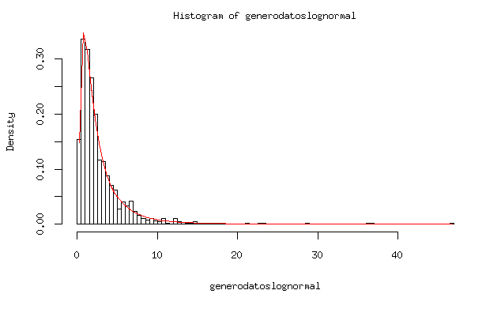

```r
# Definimos una semilla (seed) de números aleatorios, por reproducibilidad.
set.seed(42)
generodatoslognormal<-rlnorm(n=1000, meanlog=log(1.9), sdlog=log(2.5))
histogramavelocidad<-hist(generodatoslognormal,breaks=100,freq = FALSE)
#y<-histogramavelocidad$counts
y<-histogramavelocidad$density
xhistogram<-histogramavelocidad$mids
#prueba para ver si mi definicion de lognormal coincide efectivamente con la de R
#lines(xhistogram,distriblognormal(xhistogram,log(1.9),log(2.5)),col="red",ty="l")
#ajusto mi distribución a los "datos"
modelonolineal <- nls(y ~ distriblognormal(xhistogram,mu,sigma), start = list(mu=log(1.9), sigma=log(2.5)),algorithm = "plinear")
lines(xhistogram,distriblognormal(xhistogram,coef(modelonolineal)["mu"],coef(modelonolineal)["sigma"]),col="red")
```

```r
#guardo los "datos" del histograma de velocidad en un archivo
write.table(cbind(xhistogram,y),row.names=FALSE,col.names=c("velocidad_m/min","frecuencia"),"datosvelocidadgliroides.csv")
```